# VC 3.0: Riding the ChatGPT Wave

Krystal Sun

Kendelle Hung-Ino

Becca Park

Spring 2025

# 1 Executive Summary

## 1.1 Goal of the study

The goal of this study was to identify key factors that contribute to successful AI investments from both the startup and investor perspectives. By analyzing the generative AI (Gen AI) effect, U.S. government funding, and co-investor networks, this study aimed to uncover how the recent Gen AI trend and VC connectivity impact startups’ visibility in attracting funds and investors’ next-step strategies.

## 1.2 Data

#### 1.2.0.1 ai_comp_flagged

The AI companies dataset contains information on startups’ basic information including their name (including Gen AI or not), active and former investors, and primary industry focus, as well as their financing information including first and last financing time and size and the total fund raised. This dataset helps us to understand both the companies backgrounds as well as the financial metrics when evaluating their success.

#### 1.2.0.2 ai_dealinvestorrelation

The investor relations dataset contains information on the investors in the deals, detailing their name, fund name, lead partners, and IDs of the deals they were involved in. This dataset provides us with more information about where the financing is coming from and which entities are appearing in AI deals.

#### 1.2.0.3 ai_deal

The deals dataset contains information on AI startup funding rounds from 2016 to 2025, including variables such as deal size, deal type, deal date, company name, and total capital raised. It captures the timing and structure of each investment, allowing analysis of funding trends over time. This dataset forms the foundation for understanding how capital flows into the AI startup ecosystem.

## 1.3 Methods

#### 1.3.0.2 ai_dealinvestorrelation

For the investor relations dataset, we guided our approach based on our EDA findings. We saw that several of the top repeat investors in the dataset were connected to the U.S. government. Considering recent policy changes surrounding grant awarding we wanted to explore the role the U.S. government plays in the AI investment landscape. We filtered the merged data (all 3 datasets) to a subset only including deal IDs where a government agency was listed as the investor, using keywords like “United States” and “Department of”. We initially wanted to conduct the same analysis as with Gen AI for consistency purposes but the data did not have an adequate amount of the financial data to do so. We pivoted to a geospatial understanding to see what locations the companies the government is investing in and created the corresponding map visualizations.

#### 1.3.0.3 ai_deal

For the deals dataset, we first examined trends in deal volume, invested capital, and deal types over time to understand the broader landscape of AI startup funding. We created visualizations such as bar charts, boxplots, and time series plots to identify patterns in capital distribution and investor behavior. We then conducted network analysis by merging the deals dataset with the dealinvestorrelation data to construct co-investor networks using 5-year rolling windows from 2016 to 2025. Within each yearly network, we calculated centrality metrics including degree, betweenness, closeness, and eigenvector centrality to evaluate investor connectivity and influence over time.

## 1.4 Findings

#### 1.4.0.3 ai_deal

The network analysis showed a steady increase in investor interconnectedness, with both the average degree centrality and number of highly connected investors rising over time. While government agencies such as the NSF and Department of Defense initially held influential positions within the network, private investors like Y Combinator emerged as dominant players in recent years. These findings highlight a shift toward more centralized, private-sector-driven influence in AI funding networks.

# 2 Detailed analysis

### 2.0.1 Data Description

PitchBook is a comprehensive financial data platform that tracks private capital markets, including venture capital, private equity, and mergers and acquisitions. In this study, we use PitchBook to analyze investment trends in artificial intelligence (AI), focusing specifically on funding rounds, valuations, and deal types. The richness of the PitchBook dataset makes it particularly useful for capturing market dynamics before and after major shocks. Drawing inspiration from how venture capital activity responded to the sudden uncertainty introduced by COVID-19, we treat the release of ChatGPT on November 30, 2022, as a similar market shock. This allows us to explore how investor behavior, deal flow, and capital deployment in the AI space may have shifted in response to a disruptive innovation moment.

# 3 Exploratory Data Analysis (EDA)

## 3.1 EDA on the AI Company Dataset (ai_comp)

Next, we removed columns that were not directly related to the success metrics of AI startups, retaining only those variables that provide insight into their performance. Additionally, we limited the dataset to startups founded after 2016—marking the release of the first generation of GPT—to capture the surge in acquisitions and new founding activity. This filtering ensures that our analysis reflects the most recent trends in the industry. The cleaned dataset is called “ai_comp_clean.csv”.

### 3.1.1 Data cleaning

### 3.1.2 Wordcloud on keywords

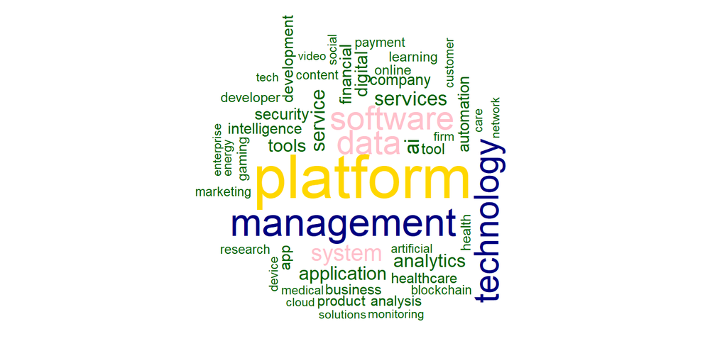

### 3.1.3 Distribution plot of totalraised

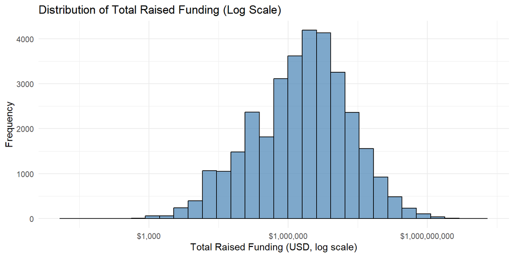

**Takeaway**: On a logarithmic scale, the total funding raised appears roughly bell-shaped, suggesting a wide range of funding amounts. Most startups cluster around lower funding levels, with a few outliers raising significantly larger sums.

### 3.1.4 Pie chart on universe

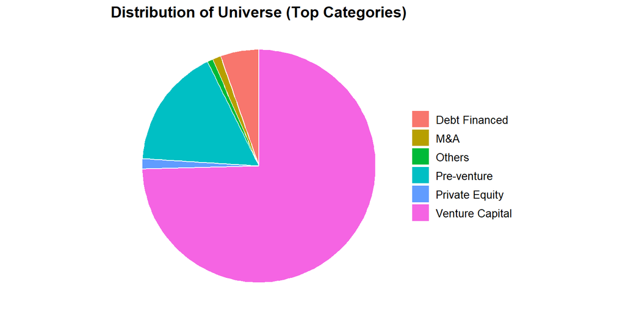

**Takeaway:** Venture Capital dominates the “Universe” category in this dataset, indicating that most startups fall under venture-backed ownership. Other categories—such as Private Equity, Other Private Companies, Pre-venture, and Debt Financed—make up smaller portions of the pie.

### 3.1.5 Bar graph on yearfounded

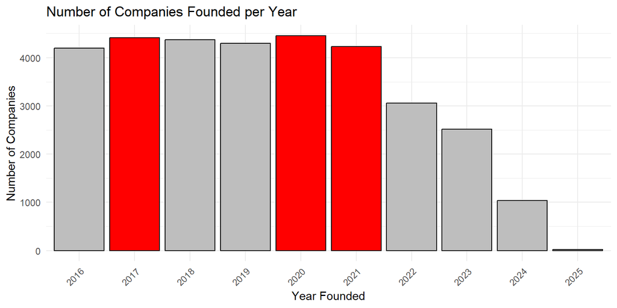

### 3.1.6 Pie chart on primaryindustrysector

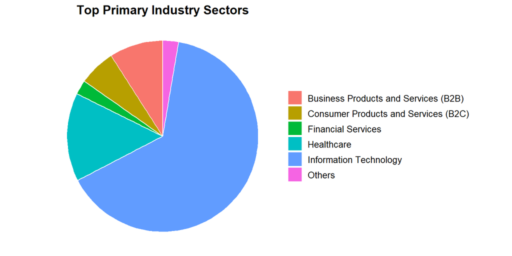

### 3.1.7 Bar graph on hqcity (top 10 cities)

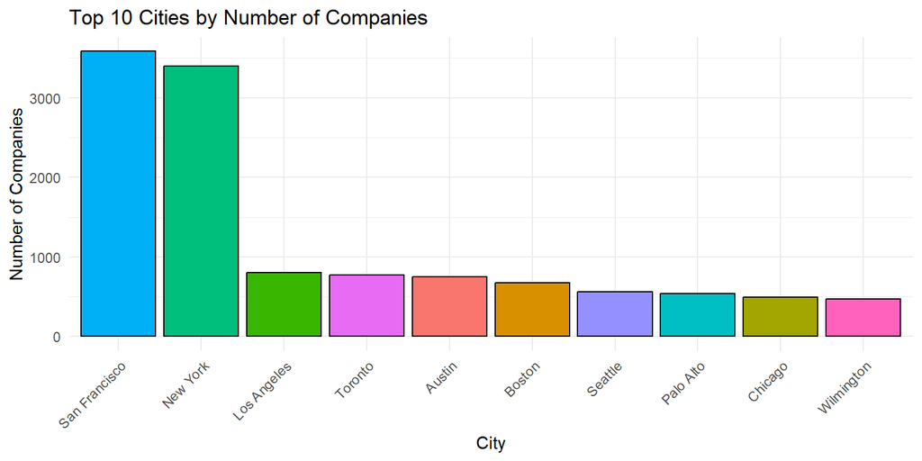

### 3.1.8 Pie chart on lastfinancingdealtype

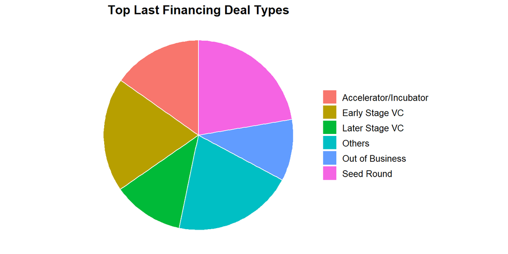

**Takeaway:** Most AI startups in this dataset secured financing through accelerators/incubators, early-stage VC, or seed rounds, indicating a strong focus on nurturing young companies. The presence of later-stage VC deals and some companies that went out of business reflects the varied paths AI startups can take as they mature.

## 3.2 EDA on the AI Deals Dataset (ai_deals)

### 3.2.1 Data cleaning

### 3.2.2 Convert date columns

### 3.2.3 Convert numeric columns stored as characters

### 3.2.4 Ensure logical columns are correctly typed

### 3.2.5 Drop columns with 100% NAs

### 3.2.6 Filter dealdate to greater than 2016

**Takeaway:** To clean the ai_deals dataset, we removed duplicate rows and rows with all missing values. We replaced empty strings with NA to standardize missing data. Then, we converted date columns like dealdate to proper date format and changed relevant numeric columns to numbers. We also made sure logical columns were correctly formatted and removed any columns that were completely empty. Lastly, we filtered the dataset to only keep deals from after the year 2016.

### 3.2.7 Histogram: Total Invested Capital

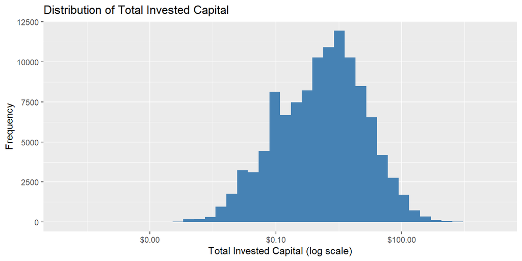

### 3.2.8 Bar Plot: Deal Status

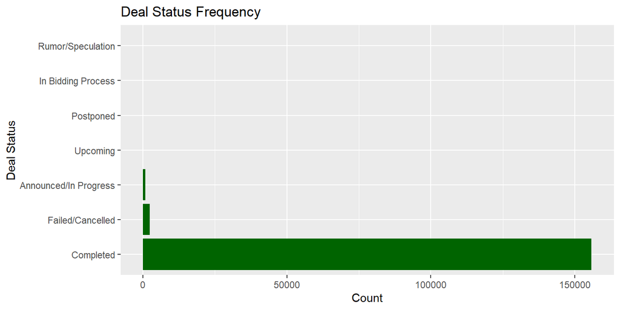

### 3.2.9 Scatter Plot: Revenue vs Total Invested Capital

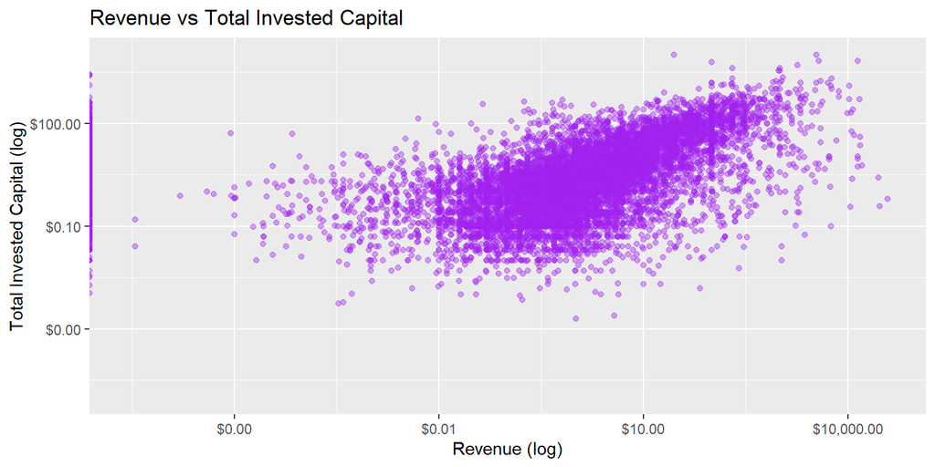

### 3.2.10 Time Series: Deals Over Time

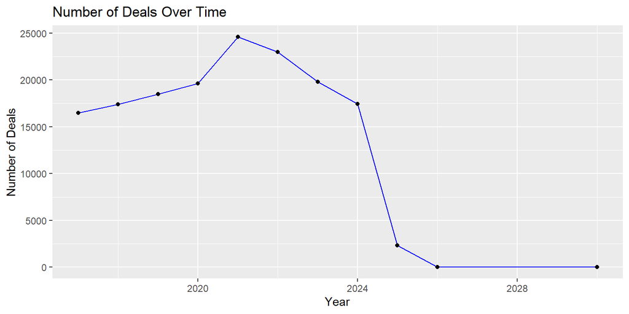

### 3.2.11 Boxplot: Total Invested Capital by Deal Type

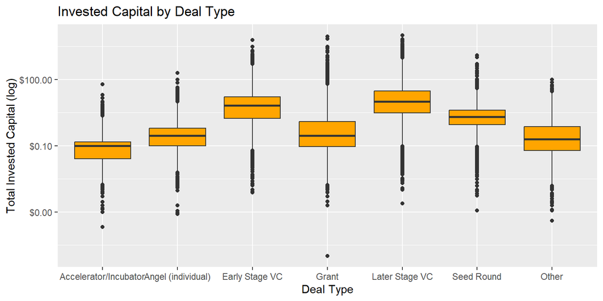

**Takeaways:** The exploratory data analysis of the ai_deals dataset revealed several key patterns. The distribution of total invested capital is right-skewed but appears log-normal when plotted on a log scale, with most investments falling between $0.10 and $10. Deal status is heavily dominated by “Completed” deals, suggesting that the dataset largely reflects finalized investments. A positive relationship is evident between revenue and total invested capital, indicating that higher-revenue companies tend to receive more investment. The number of deals increased steadily from 2017 and peaked around 2021, followed by a sharp decline in later years—likely due to data incompleteness for future dates. Finally, when examining deal types, early and later stage venture capital deals generally attracted higher investment amounts compared to other types like seed rounds or grants, as shown in the boxplots

## 3.3 EDA on the AI Deals Investor Relations (ai_dealinvestorrelation)

### 3.3.1 Understand Data Variables

### 3.3.2 Inital Data Cleaning

### 3.3.3 Missing Values

### 3.3.4 Exploring Relationships

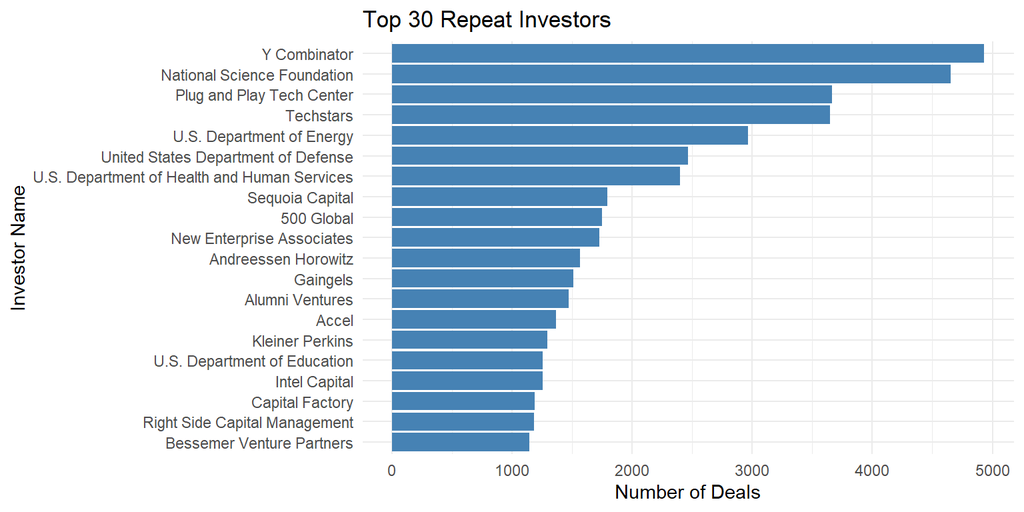

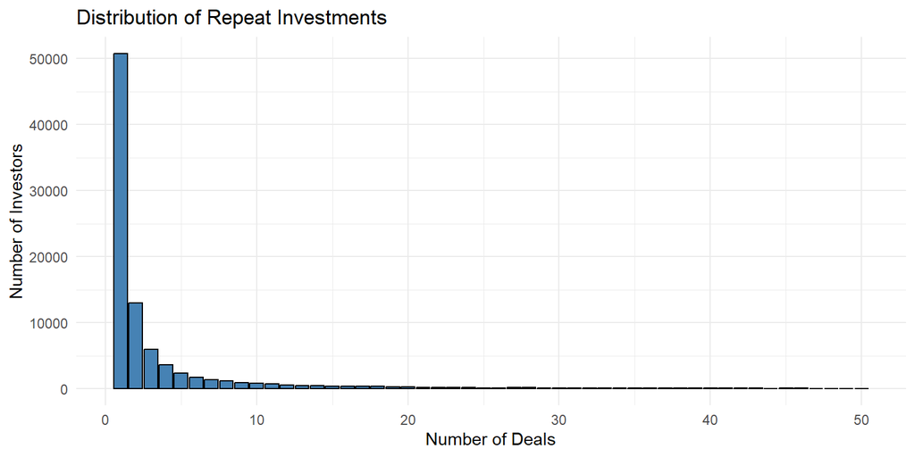

**Takeaway:** While there are many companies that have invested several times within the data set we see that a majority of the investors in the data are seen in only 1 deal. This leads to future opportunities to explore what type of companies are investing, if they are related to the AI’s market or just general tech investors. The U.S., through different departments and agencies, appears several times in top repeat investor graph.

# 4 In Depth Analysis

## 4.1 Deeper Analysis on AI Companies Dataset (ai_comp_flagged)

### 4.1.1 Total Raised as the success metrics: below and above average

### 4.1.2 Separate Gen AI and Non Gen AI companies

### 4.1.3 Create Time Duration Until First Financing

### 4.1.4 Pie Chart on Percentage of Success by Gen AI vs. Non Gen AI companies

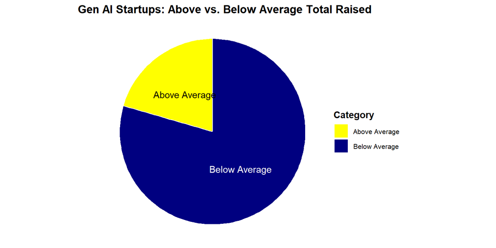

**Takeaway:** Gen AI startups have a higher chance of getting above average fund (totalraised).

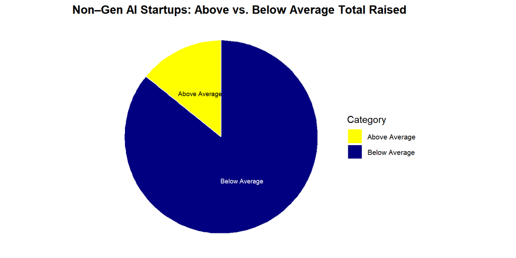

**Takeaway:** Non-Gen AI startups have a lower chance of getting above average fund (totalraised).

### 4.1.7 Top 10% Total Fund Raised (90% AI startups fail in the first 3 years)

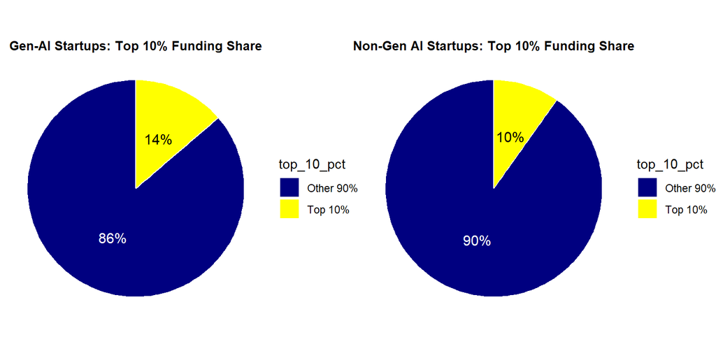

**Takeaway:** According to Edge Delta in the AI Startup Statistics in 2024, around 90% of startups fail in their first few years of operation. So taking one step further to see the breakdowns of Gen AI vs. Non Gen AI startups making to the top 10% total fund raised, we still can see that there is a higher percentage of startups making to the top 10% if they are Gen AI related. (14% for Gen AI companies vs. 10% Non Gen AI companies)

### 4.1.8 Logistic Regression

## 4.2 Deeper Analysis on AI Investor Relations Dataset (ai_dealinvestorrelation)

### 4.2.1 Load Merged Data

### 4.2.2 Filtering Government Deals

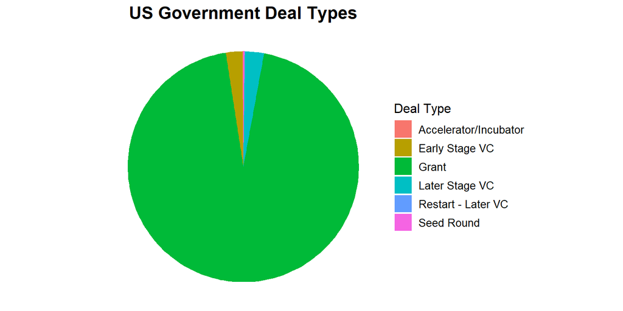

**Takeaway**: A large majority of U.S. AI investments in the data are of grant deal type. This supports our hypothesis that changes in grant awarding will have an affect on the AI investment landscape.

### 4.2.4 Geospatial Understanding of Govt. Deals

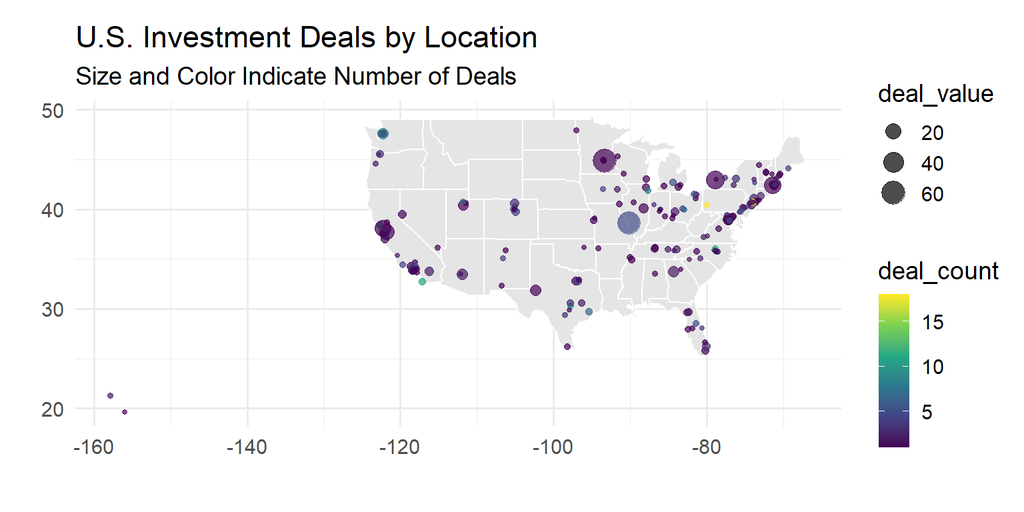

[figure not shown]

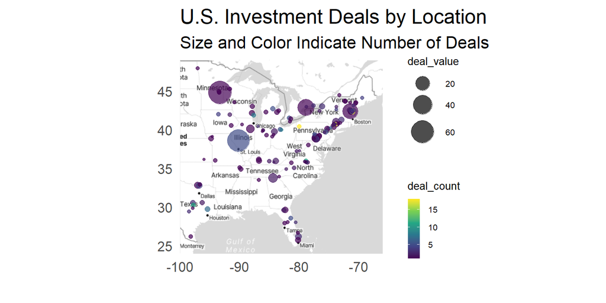

## 4.3 Deeper Analysis on AI Deals Dataset (ai_deals)

### 4.3.1 Combining ai_deals with deal_investor datasets

**Takeaway:** We first began by filtering all AI startup deals after 2016, keeping only those with over $5 million in total investment and at least three distinct investors. We then merged investor participation data with startup deal data using dealid to link each investor to each deal. For every startup, we generated co-investor pairs to form the edges of our network. Using rolling 5-year windows, we built annual co-investor networks from 2016 to 2025. Finally, we calculated key centrality metrics—degree, betweenness, closeness, and eigenvector—for each investor to assess their connectivity and influence in the AI startup funding landscape.

### 4.3.2 Save as new dataset

*We output the network data into a new csv file to save time when running the code again.*

### 4.3.3 Plot average degree centrality per year

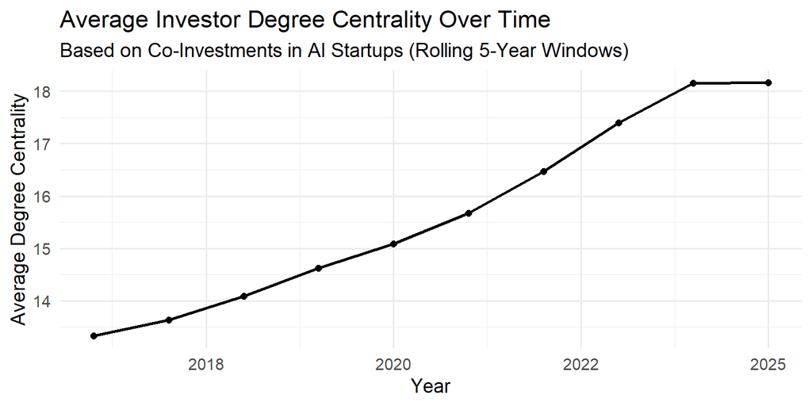

**Takeaway:** From this visual, we see that the average degree centrality among investors steadily increased from 2016 to 2025, indicating that investors are forming more co-investor connections and that the AI funding network became more densely interconnected over time. We believe that co-investor centrality rose steadily as the AI sector matured and investors increasingly syndicate deals.

### 4.3.4 Plot investor degree centrality over time

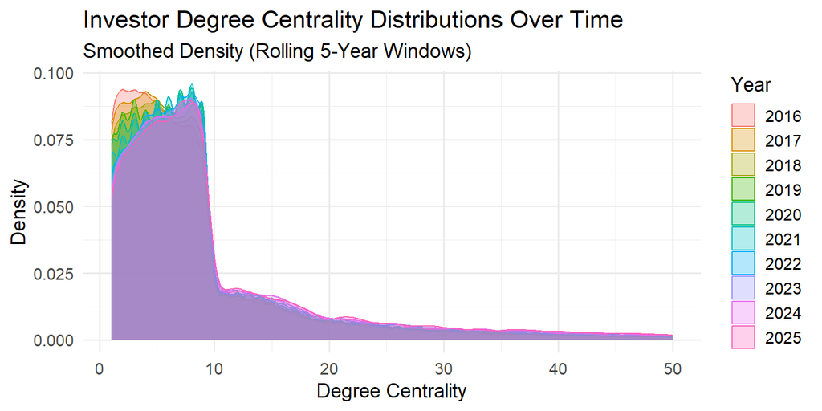

**Takeaway:** From the the smoothed density plot, we can see the distribution of investor degree centrality over time, using rolling 5-year windows from 2016 to 2025. While the overall shape of the distribution remains right-skewed across all years—indicating that most investors have relatively few co-investor connections, we do see a subtle rightward shift is visible over time. This mean that there is a gradual increase in the number of investors with higher degree centrality, meaning more investors are becoming connected to a broader network of co-investors in the AI funding landscape.

### 4.3.5 Plot top 10 investors by degree centrality

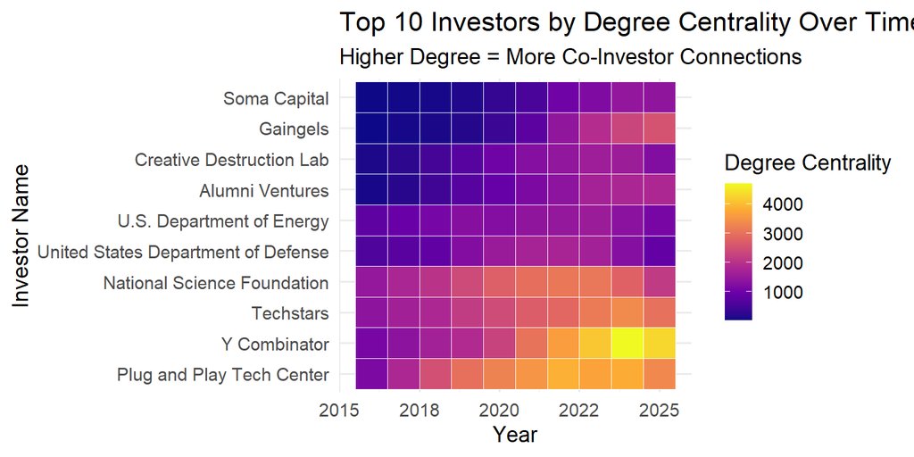

**Takeaway:** From the heatmap showcasing top 10 investors by degree centrality over time, we see that a few key investors, like Y Combinator and Plug and Play Tech Center, dramatically increased their co-investor connections over time, strengthening their central role in the AI startup funding network. For instance, the plot shows that Y Combinator has around 4000 direct partnership with different investors.

### 4.3.6 Plot number of highly connected investors

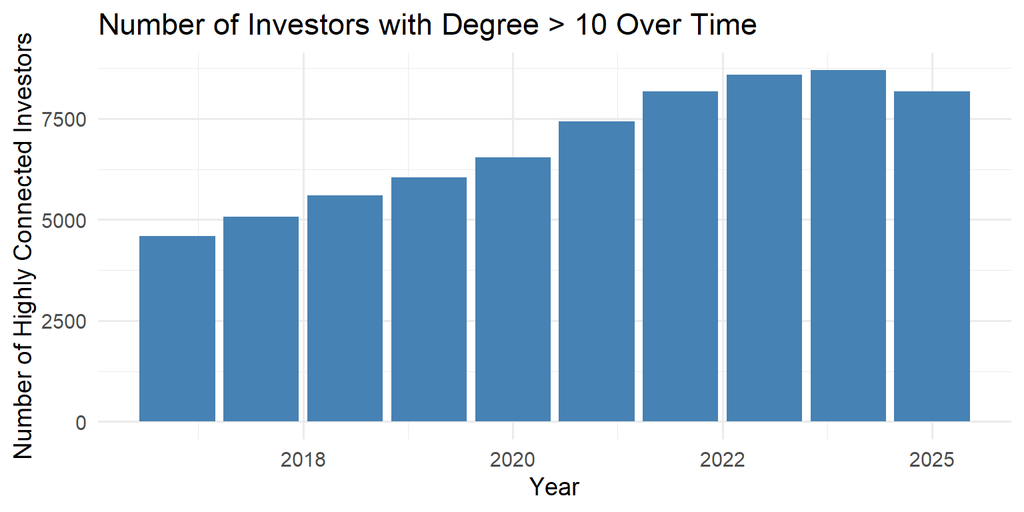

**Takeaway:** From the bar chart that shows the number of investors with degrees centrality greater than 10 over time, that the number of highly connected investors (those with more than 10 co-investor ties) steadily increased from 2016 to 2023, showing that a growing share of investors became deeply embedded in the AI startup funding network. Interestingly, this trend plateaus after 2022, possibly due to economic tightening, but may also reflects how post-ChatGPT, investors began clustering around fewer high-profile GenAI startups.

### 4.3.7 Top strategic investors based on eigenvector centrality

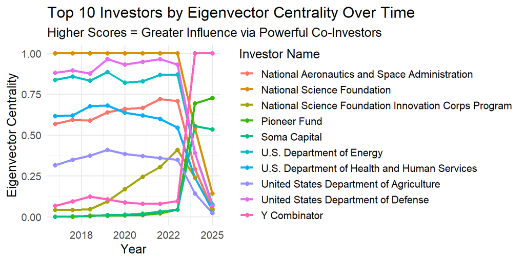

**Takeaway:** We next wanted to see how eigenvector centrality metrics impacted the existing trends we saw from degrees centrality. The plot showcases that government agencies like the National Science Foundation and U.S. Department of Defense initially dominated the AI funding network by influencing powerful co-investor groups, but recent years show a rise in private investors like Y Combinator gaining network influence.

### 4.3.8 Top investors: degree vs eigenvector centrality

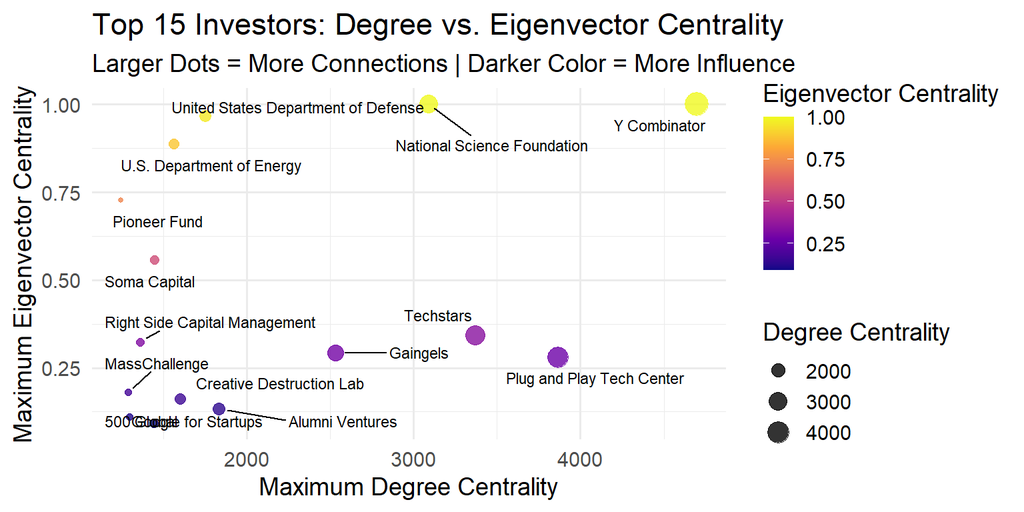

**Takeaway:** We next wanted to see how eigenvector centrality and degree centrality (quantity vs. quality) impacts investor patterns. We see that while accelerators like Y Combinator combined both high connectivity and high influence, many investors with large networks, like Plug and Play Tech Center, had lower influence scores, highlighting that who you connect with matters more than just how many connections you have.

# 5 Conclusion

### 5.0.2 U.S. Government Effect

Given grant policy changes, AI startup founders in the Northeast can expect a decrease in the chances of receiving government funding. It may be advised to base the startup in Silicon Valley since this is where many other investors are looking. For AI investors, since the large majority of U.S. involvement in the AI landscape was through grants, they can expect “less” competition and may also want to look at viable startups in the Northeast.

### 5.0.3 VC Network Effort

Overall, the network analysis reveals a growing interconnectedness among AI startup investors, with average degree centrality steadily rising from 2016 to 2025. U.S. government agencies initially dominated the network in terms of influence, but recent years have seen private accelerators like Y Combinator surpass them in both connectivity and centrality. Furthermore, the number of highly connected investors has expanded over time, signaling a more collaborative funding environment. For founders, these insights emphasize the importance of tapping into highly connected and influential investors to boost your startup’s visibility and co-investor backing early. For investors, they point to the value in favoring startups backed by well-networked investors since strong networks often signal better follow-on funding and faster scaling.

# 6 Appendix

## 6.1 Extra Credit: Shiny App

### 6.1.1 Logistic Regression

## 6.2 Data Cleaning

### 6.2.1 ai_comp_flagged

For the AI companies dataset, we first pared down the original AI companies table to only the fields I needed—IDs, names, descriptions, key dates and financing details, industry and location attributes, growth metrics, and AI‐specific flags. Next, we filtered out any firms founded before 2016. I then converted several categorical columns (universe, industry sector/group/code) into factors for modeling readiness, and scaled the `totalraised` variable from millions to actual dollar values. Finally, we exported the cleaned data to “ai_comp_clean.csv” and listed its column names to verify that only the intended fields remained.

### 6.2.2 ai_dealinvestorrelation

For the AI Investor Relations dataset, we used a merged dataset to supplement its initial information. We first used a merge of the ai_dealinvestorrelation and ai_deal to explore relationships within the U.S. government subset. We filtered for keywords indicating that the investor_name column was connected to the government (i.e. “U.S.”, “United States”) and created a subset including only deals where the U.S. was an investor. To conduct the map visualizations, we merged ai_companies to obtain the city and state of where the U.S.-backed startups were located. Fitlering based on NAs was applied to visualize the size of deals, and filtering was done to reduce the data to government entities that frequently invested.

## 6.3 Data dictionary

You can find additional documentation on the data source here.

## 6.4 Work Distribution

- Krystal: Worked on all EDA and detailed analysis on the AI Companies Dataset, including the Shiny App.
- Kendelle: Worked on all EDA and detailed analysis on the AI Investor Relations Dataset.
- Becca: Worked on all EDA and detailed analysis on the AI Deals Dataset.
- Everyone worked on the Executive Summary and Conclusion sections of the report.

## 6.5 Usage of Generative AI

### 6.5.1 ai_comp_flagged

For the Gen AI Effect section, Chat GPT was used to flag the companies with top 10% total fund raised into a new sub-dataset. It was also used to help modify the codes to unify the percentage breakdown pie charts’ color schemes of Gen AI vs. Non Gen AI companies. Chat GPT was used to prepare for the logistic regression data frame as well as the ShinyApp.

### 6.5.2 ai_dealinvestorrelation

For the U.S. government Effect section, Chat GPT was used to help create the 2 map visualizations so that the size and color of the circles could reflect the value and frequency of deals.

### 6.5.3 ai_deals

For the Network Analysis section, Chat GPT was used to help create the network, specifically on helping to narrow down the dataset so it could properly run (filtering for deals with total investment ≥ $5 million and companies with at least 3 distinct investors). Furthermore, Chat GPT was used to help create the plot detailing the top 15 investors by degree and eigenvector centrality.

…